# Process genomic in silico pairwise perturbations

Melanie (1028-02098-001-001)

January 07, 2022

# Introduction

The goal of this analysis is to assess the effect of pairwise mutations of the model. Using measures of log2 FC as described in Avsec et al 2021, we will measure the cooperativity association between TFs upon pairwise mutation across motifs.

Additionally, we will look at whether enhancer patterning groups make a difference in terms of TF cooperativity.

# Computational Setup

```r
#Standard packages
library(rtracklayer) ; library(GenomicRanges); library(magrittr) ; library(Biostrings)
library(ggplot2) ; library(reshape2); library(plyranges); library(Rsamtools)
library(dplyr); library(data.table); library(patchwork); library(readr); library(testit)

#KNITR Options
setwd("/n/projects/mw2098/publications/2022_maven_ISL1/analysis/")
options(knitr.figure_dir="../figures/6_pairwise_genomic_perturbs", java.parameters = "- Xmx6g")

#Lab sources
source("../scripts/granges_common.r")
source("../scripts/metapeak_common.r")
source("../scripts/knitr_common.r")
source("../scripts/caching.r")
source("../scripts/metapeak_functions.R")

#Specific sources
library(ggseqlogo)
library(stringr)
source("scripts/variables.r")
source("../scripts/motif_functions.r")
source("../scripts/perturb_functions.r")

#Pre-existing variables

#TFs have a one-to-many association with motifs.
motif_specs.list<-list(
  `NKX2.5` = list(color = '#391b40', tf = "I_WT_D6CM"),
  GATA = list(color = '#914236', tf = "I_WT_D6CM"),
  ISL1 = list(color = '#d77d49', tf = "I_WT_D6CM"),
  `NKX2.5-alt` = list(color = '#00565f', tf = "I_WT_S3MN"),
  LHX = list(color = '#7faaaf', tf = "I_WT_S3MN"),
  `LHX-ISL1-28` = list(color = '#7f92af', tf = "I_WT_S3MN"),
  `LHX-ISL1-10` = list(color = '#7f92af', tf = "I_WT_S3MN"),
  `LHX-ISL1-9` = list(color = '#7f92af', tf = "I_WT_S3MN"),
  Onecut2 = list(color = '#7f92af', tf = "I_WT_S3MN"),
  NeuroD = list(color = '#af7f92', tf = "I_WT_S3MN"),
  EBF1 = list(color = '#af7f92', tf = "I_WT_S3MN")
)
perturb_motifs.path<-'tsv/perturbs/all_instances_curated_formatted_0based.tsv.gz'
```

# Import and format motifs of interest

Add `pattern_name_unique` and `example_idx` (placeholder for `region_id`) for matching regions with the genomic perturbation files.

```r
motifs.df<-read.table(perturb_motifs.path, header = T, sep = '\t') %>%
  dplyr::group_by(example_idx, pattern_name) %>%
  dplyr::mutate(motif_num = dplyr::row_number(),
                pattern_name_unique = paste0(pattern_name, "-", motif_num))
motifs.df$pattern_center <- motifs.df %>% dplyr::select(example_chrom, pattern_start, pattern_end, strand) %>%
  makeGRangesFromDataFrame(starts.in.df.are.0based = T, seqnames.field = 'example_chrom', start.field = 'pattern_start', end.field = 'pattern_end') %>%
  resize(1, 'center') %>% start()
```

# Identify unique motif pairs

We will look at all motif pairs, including duplicate pairs.

```r
motif_combinations<-rbind(
  combn(names(motif_specs.list), m = 2) %>% t %>% as.data.frame(),
  data.frame(V1=names(motif_specs.list),
             V2=names(motif_specs.list)))
colnames(motif_combinations)<-c("x", "y")
```

# Collect pairwise perturbations

Collect perturbations but filter out any motif pairs that overlap at all in order to avoid mapping synergy between redundant coordinates. Here, we want to see pure synergy between motif groups and their relative differences.

```r
#Collect perturbations with overlaps allowed
filler<-lapply(c('all'), function(y){

  #pre-emptively read perturbs in
  perturb_prefix <- paste0("perturbs_", y)
  perturb_files<-list.files(path = "tsv/perturbs", pattern = perturb_prefix, full.names = T) %>% grep('chr', ., value = T)
  perturbs_all.list<-mclapply(perturb_files, read_tsv, mc.cores = 6)
  names(perturbs_all.list)<-perturb_files %>% basename(.) %>% gsub(pattern = perturb_prefix, '', .) %>% gsub('.tsv.gz', '', .) %>% gsub('_', '',.)

  perturbs.list<-lapply(1:nrow(motif_combinations), function(x){
    message(motif_combinations$x[x], ", ", motif_combinations$y[x])

    #find all unique motif pairs
    pairs.df<-find_motif_pairs(name_x = motif_combinations$x[x], name_y = motif_combinations$y[x], dfi = motifs.df, remove_overlapping = T) %>%
      dplyr::filter(!grepl('gl', example_chrom.x))

    #extract and summarize perturbations
    perturb.df<-extract_whole_window_paired_perturbs(pairs.df = pairs.df,
                                                     motif_specs.list = motif_specs.list,
                                                     perturb_prefix = perturbs_all.list)
    return(list(pair = pairs.df, perturb = perturb.df))
  })

  write_tsv(perturbs.list %>% lapply(., function(x) x$perturb) %>% rbindlist,
            paste0("tsv/perturbs/perturbs_", y, "bp_2motifs_all_overlaps_no.tsv.gz"))
  write_tsv(perturbs.list %>% lapply(., function(x) x$pair) %>% rbindlist,
            paste0("tsv/perturbs/pairs_", y, "bp_2motifs_all_overlaps_no.tsv.gz"))
  return(NULL)
})

#Collect perturbations with overlaps allowed
filler<-lapply(c('500bp'), function(y){

  #pre-emptively read perturbs in
  perturb_prefix <- paste0("perturbs_", y)
  perturb_files<-list.files(path = "tsv/perturbs", pattern = perturb_prefix, full.names = T)
  perturbs_all.list<-mclapply(perturb_files, read_tsv, mc.cores = 6)
  names(perturbs_all.list)<-perturb_files %>% basename(.) %>% gsub(pattern = perturb_prefix, '', .) %>% gsub('.tsv.gz', '', .) %>% gsub('_', '',.)

  perturbs.list<-lapply(1:nrow(motif_combinations), function(x){
    message(motif_combinations$x[x], ", ", motif_combinations$y[x])

    #find all unique motif pairs
    pairs.df<-find_motif_pairs(name_x = motif_combinations$x[x], name_y = motif_combinations$y[x], dfi = motifs.df, remove_overlapping = T) %>%
      dplyr::filter(!grepl('gl', example_chrom.x))

    #extract and summarize perturbations
    perturb.df<-extract_motif_window_paired_perturbs(pairs.df = pairs.df,
                                                     motif_specs.list = motif_specs.list,
                                                     perturb_prefix = perturbs_all.list)
    return(list(pair = pairs.df, perturb = perturb.df))
  })

  write_tsv(perturbs.list %>% lapply(., function(x) x$perturb) %>% rbindlist,
            paste0("tsv/perturbs/perturbs_", y, "bp_2motifs_all_overlaps_no.tsv.gz"))
  write_tsv(perturbs.list %>% lapply(., function(x) x$pair) %>% rbindlist,
            paste0("tsv/perturbs/pairs_", y, "bp_2motifs_all_overlaps_no.tsv.gz"))
  return(NULL)
})
```

# Perturbation functions

Given a set of perturbations from extract_whole_window_paired_perturbs or extract_motif_window_paired_perturbs, compute the cooperativity: `fc = (WT - (dA_a - dA_ab) + pc_ab) / (dA_b + pc_b)` as per Avsec et al 2021.

After measuring the cooperativity, summarize the values of each motif pair instance by distance_category or distance directly.

## Function to measure cooperativity

```r
collect_cooperative_metrics<-function(perturbs.df, motif_specs.list, measurement = "pred_sum", dist_min = 6, dist_max = 1000, summarize = T){

  #Collect perturbations and calculate cooperativity measures.
  perturbs.df$distance_class<-cut(abs(perturbs.df$distance_b_minus_a), include.lowest = T,
                                  breaks = c(0, 35, 70, 150, Inf),
                                  labels = c("protein-range", "mid-range", "nucleosome-range", "long-range"))

  perturbs.df$distance_abs<-perturbs.df$distance_b_minus_a %>% abs
  if(measurement == "pred_sum"){
    perturbs.df<-perturbs.df %>% dplyr::mutate(
      fc = (`WT/pred_sum` - (`dA_a/pred_sum` - `dA_ab/pred_sum`) + `WT/pc`) / (`dA_b/pred_sum` + `dA_b/pc`))
  } else {
    perturbs.df<-perturbs.df %>% dplyr::mutate(
      fc = (`WT/pred_max` - (`dA_a/pred_max` - `dA_ab/pred_max`) + `WT/pc`) / (`dA_b/pred_max` + `dA_b/pc`))
  }
  perturbs.df$motif_pair_AB<-paste(perturbs.df$motifA, perturbs.df$motifB, sep = "_")

  if(summarize){
    #Summarize perturbations across distance class
    perturb_summary_cat.df<-perturbs.df %>%
      dplyr::group_by(motifA, motifB, distance_class) %>%
      dplyr::summarize(fc_avg = mean(fc, na.rm = T), fc_med = median(fc, na.rm = T),
                       count = n())
    motif_order<-names(motif_specs.list)
    tf_order<-lapply(motif_specs.list, function(x) x$tf) %>% unlist
    perturb_summary_cat.df$motifB<-factor(perturb_summary_cat.df$motifB, levels = motif_order,
                                          labels = paste0("KO: ", motif_order))
    perturb_summary_cat.df$motifA<-factor(perturb_summary_cat.df$motifA, levels = motif_order,
                                          labels = paste0(tf_order, " at ", motif_order))

    #Summarize perturbations across distance directly
    perturb_summary_dist.df<-perturbs.df %>%
      dplyr::filter(distance_abs <= dist_max & distance_abs >= dist_min) %>%
      dplyr::group_by(motifA, motifB, distance_abs) %>%
      dplyr::summarize(fc_avg = mean(fc, na.rm = T), fc_med = median(fc, na.rm = T),
                       count = n())

    perturb_summary_dist.df$motif_pair_general<-lapply(1:nrow(perturb_summary_dist.df), function(x){
      A<-perturb_summary_dist.df$motifA[x] %>% as.character
      B<-perturb_summary_dist.df$motifB[x] %>% as.character
      if(A > B){return(paste0(B, "_",A))} else{return(paste0(A, "_", B))}
    }) %>% unlist
    perturb_summary_dist.df$motif_pair_specific<-paste0(perturb_summary_dist.df$motifA, " when KO ", perturb_summary_dist.df$motifB)
    perturb_summary_dist.df$motifA<-factor(perturb_summary_dist.df$motifA, levels = motif_order,
                                           labels = paste0(tf_order, " at ", motif_order))

    return(list(measurement = measurement, perturb_by_cat = perturb_summary_cat.df, perturb_by_dist = perturb_summary_dist.df))
  } else{
    return(list(measurement = measurement, perturbs = perturbs.df))
  }

}
```

## Function to plot cooperativity across distance_cat

Given the summary values binned by distance_cat, generate a heatmap of values.

```r
plot_cooperativity_across_distance_cat<<-function(perturb_summary.df, fill_column, output_prefix = NA,
                                                  height = 3.5, width = 12,
                                                  title = NA, subtitle = NA, fill_limits = c(-1, 1)){
  perturb_summary.df$cooperativity_column<-perturb_summary.df[[fill_column]]

  g<-ggplot(perturb_summary.df, aes(x = motifB, y=motifA))+
    geom_tile(aes(fill = log2(cooperativity_column)))+
    # geom_text(aes(label = count))+
    scale_fill_gradient2(high = "#b2182b", mid = "white", low = "#2166ac",
                         midpoint = 0, limits = fill_limits, name = paste0("log2(", fill_column, ")"))+
    facet_wrap(~ distance_class, nrow = 1)+
    ggtitle(title, subtitle = subtitle) +
    theme_bw()+
    theme(axis.text.x = element_text(angle = 45, hjust = 1))

  if(!is.na(output_prefix)){
    ggsave(paste0(output_prefix, ".pdf"), g, height = height, width = width)
    ggsave(paste0(output_prefix, ".png"), g, height = height, width = width)
  }
  return(g)
}
```

## Function to plot cooperativity across distance

Given the summary values binned by distance, generate a set of cooperative line-plots showing the effect of each motif on its pair.

```r
plot_cooperativity_across_distance<-function(perturb_summary.df, y_column, output_prefix = NA,
                                              width = 16, upper_dist = 250, facet_scaled = "free",
                                              title = NA, subtitle = NA, motif_colors){
  perturb_summary.df$cooperativity_column<-perturb_summary.df[[y_column]]
  panel_count<-perturb_summary.df %>% group_by(motifA, motifB) %>% count() %>% nrow()

  g<-ggplot(perturb_summary.df, aes(x = distance_abs, y=log2(cooperativity_column)))+
    geom_hline(yintercept = 0, color = "black", linetype = "dotted")+
    geom_line(aes(color = motifA))+
    scale_x_continuous(breaks = seq(0, upper_dist, 20), minor_breaks = seq(0, upper_dist, 10), limits = c(0, upper_dist))+
    scale_y_continuous(name = paste0("log2(", y_column, ")"))+
    scale_color_manual(values = motif_colors, name = "TFA @ MotifA")+
    facet_wrap(~motif_pair_general, ncol = 4, drop = T, scales = facet_scaled)+
    ggtitle(title, subtitle = subtitle) +
    theme_minimal()+
    theme(axis.text.x = element_text(angle = 45, hjust = 1),
          panel.grid.major.y = element_blank(), panel.grid.minor.y = element_blank())

  if(!is.na(output_prefix)){
    ggsave(paste0(output_prefix, ".pdf"), g, height = ceiling(panel_count/2), width = width)
    ggsave(paste0(output_prefix, ".png"), g, height = ceiling(panel_count/2), width = width)
  }
  return(g)
}
```

# Summarize perturbations across all motifs

```r
motifs_all.df<-readr::read_tsv('tsv/perturbs/all_instances_curated_formatted_0based.tsv.gz')
pairs_all.df<-readr::read_tsv('tsv/perturbs/pairs_500bpbp_2motifs_all_overlaps_no.tsv.gz')
perturbs_all.df<-readr::read_tsv('tsv/perturbs/perturbs_500bpbp_2motifs_all_overlaps_no.tsv.gz')

perturbs_all_summary.df<-collect_cooperative_metrics(perturbs.df = perturbs_all.df,
                                                     motif_specs.list = motif_specs.list,
                                                     measurement = 'pred_max')
head(perturbs_all_summary.df)
```

```
## $measurement
## [1] "pred_max"
##
## $perturb_by_cat
## # A tibble: 483 x 6
## # Groups:   motifA, motifB [121]
##    motifA            motifB   distance_class   fc_avg fc_med count
##    <fct>             <fct>    <fct>             <dbl>  <dbl> <int>
##  1 I_WT_S3MN at EBF1 KO: EBF1 protein-range     1.03   1.02     58
##  2 I_WT_S3MN at EBF1 KO: EBF1 mid-range         1.02   1.02     86
##  3 I_WT_S3MN at EBF1 KO: EBF1 nucleosome-range  1.00   1.00    198
##  4 I_WT_S3MN at EBF1 KO: EBF1 long-range        0.998  0.999    64
##  5 I_WT_S3MN at EBF1 KO: GATA protein-range     0.996  0.990    61
##  6 I_WT_S3MN at EBF1 KO: GATA mid-range         0.988  0.988    97
##  7 I_WT_S3MN at EBF1 KO: GATA nucleosome-range  0.975  0.981   139
##  8 I_WT_S3MN at EBF1 KO: GATA long-range        0.976  0.982   118
##  9 I_WT_S3MN at EBF1 KO: ISL1 protein-range     1.03   1.01     30
## 10 I_WT_S3MN at EBF1 KO: ISL1 mid-range         1.00   0.998    65
## # … with 473 more rows
##
## $perturb_by_dist
## # A tibble: 21,830 x 8
## # Groups:   motifA, motifB [121]
##    motifA            motifB distance_abs fc_avg fc_med count motif_pair_general
##    <fct>             <chr>         <dbl>  <dbl>  <dbl> <int> <chr>
##  1 I_WT_S3MN at EBF1 EBF1             11  1.16    1.16     2 EBF1_EBF1
##  2 I_WT_S3MN at EBF1 EBF1             12  0.997   1.00     4 EBF1_EBF1
##  3 I_WT_S3MN at EBF1 EBF1             13  1.01    1.01     6 EBF1_EBF1
##  4 I_WT_S3MN at EBF1 EBF1             15  1.03    1.05     6 EBF1_EBF1
##  5 I_WT_S3MN at EBF1 EBF1             16  1.02    1.02     2 EBF1_EBF1
##  6 I_WT_S3MN at EBF1 EBF1             17  1.00    1.01     4 EBF1_EBF1
##  7 I_WT_S3MN at EBF1 EBF1             18  1.03    1.03     2 EBF1_EBF1
##  8 I_WT_S3MN at EBF1 EBF1             19  1.02    1.02     2 EBF1_EBF1
##  9 I_WT_S3MN at EBF1 EBF1             21  1.08    1.08     2 EBF1_EBF1
## 10 I_WT_S3MN at EBF1 EBF1             24  1.02    1.02     6 EBF1_EBF1
## # … with 21,820 more rows, and 1 more variable: motif_pair_specific <chr>
```

## Plot across distance categories

Take all the perturbations across all the motifs and plot their synergistic responses to one another. If there is no cooperativity or antagonistic response, then the boxes will appear white.

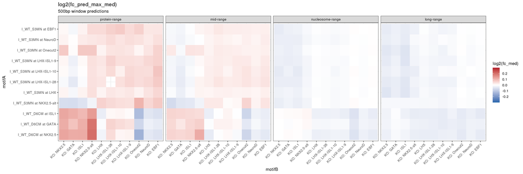

```r
synergy_cat_summary.plot<-plot_cooperativity_across_distance_cat(perturb_summary.df = perturbs_all_summary.df$perturb_by_cat, fill_column = 'fc_med',
                                                                 output_prefix = '../figures/6_pairwise_genomic_perturbs/fc_med_cat_perturbs_500bp',
                                                                 title = 'log2(fc_pred_max_med)', subtitle = '500bp window predictions',
                                                                 fill_limits = c(-.3, .3),height = 6, width = 18)
synergy_cat_summary.plot
```

Here we can see that the mapped motif groups using CWM-scanning rarely assign motifs in the same island window that contain different grammars. Additionally, there is not a strong indication of hierarchy, but we do see that the CP and MN-specific motifs have within-type cooperativity.